# Uvod u vizualizaciju podataka u R-u - Vežbe

Petar Bursać, Milutin Pejović

02 December 2020

# Vizualizacija podataka u R-u

Vizualizacija podataka podrazumeva kreiranje različitih vrsta grafika i odnosno prikaza podataka u cilju otkrivanja informacija koje na prvi pogled nisu tako uočljive. `R` ima tri odvojena okruženja za kreiranje grafika, `base`, `Lattice` i `ggplot`. U poslednje vreme `ggplot` je daleko najpopularniji paket i upravo on doprinosi velikoj popularizaciji R-a. Sa druge strane `base` plot nikada neće izaći iz upotrebe medju R korisnicima. Njega odlikuje jednostavnost poziva funkcija.

## `ggplot2`

`ggplot2` je daleko najpopularnije okruženje za kreiranje grafika. `ggplot2` predstavlja implementaciju poznatog pristupa poznatog po nazivu “The Grammar of Graphics” koji je predstavljen u istoimenoj knjizi autora Leland Wilkinson-a. Ovaj pristup je zasnovan na lejerskoj kompoziciji grafika.

> Zadatak 3: + Pokušajte da reprodukujete sledeće grafike:

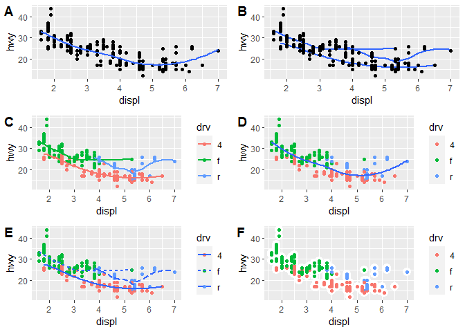

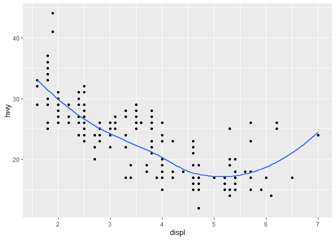

```r
ggplot(mpg, aes(x = displ, y = hwy)) +
  geom_point() +
  geom_smooth(se = FALSE) # se - confidence interval
```

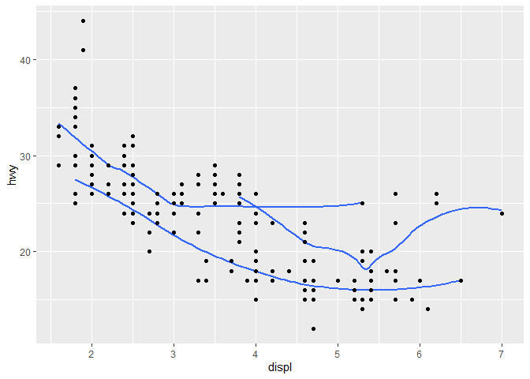

```r
ggplot(mpg, aes(x = displ, y = hwy)) +
  geom_smooth(mapping = aes(group = drv), se = FALSE) + # f = front-wheel drive, r = rear wheel drive, 4 = 4wd
  geom_point()
```

```r
# grupisanje po vrednosti kategoričke promenljive - atribut drv
```

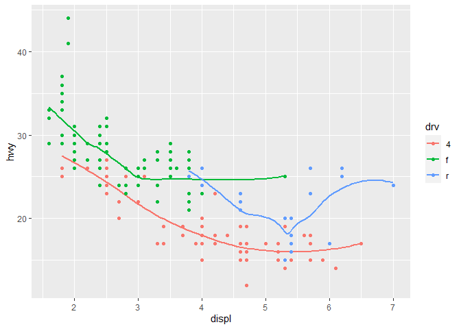

```r
ggplot(mpg, aes(x = displ, y = hwy)) +
  geom_smooth(mapping = aes(group = drv, colour = drv), se = FALSE) +
  geom_point(mapping = aes(colour = drv))
```

```r
# ILI

#ggplot(mpg, aes(x = displ, y = hwy, colour = drv)) +
#  geom_point() +
#  geom_smooth(se = FALSE)
```

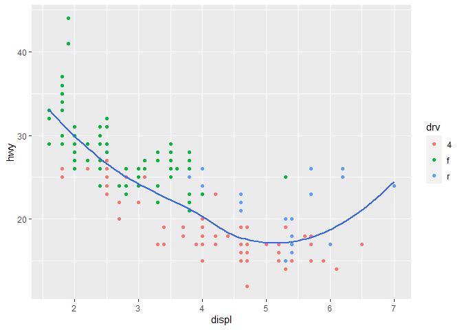

```r
ggplot(mpg, aes(x = displ, y = hwy)) +
  geom_point(aes(colour = drv)) +
  geom_smooth(se = FALSE)
```

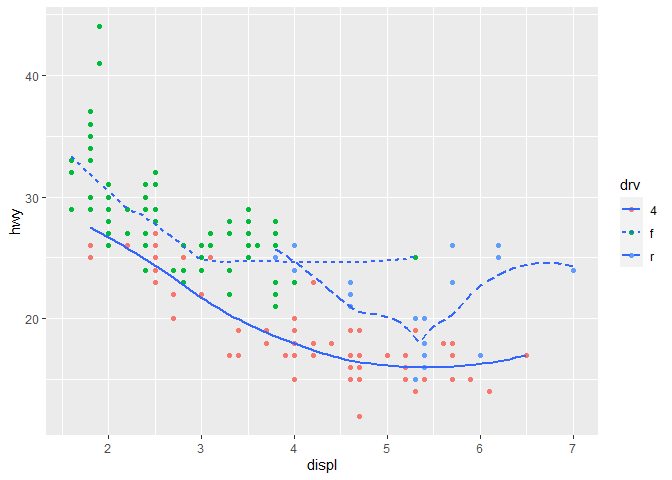

```r
ggplot(mpg, aes(x = displ, y = hwy)) +
  geom_point(aes(colour = drv)) +
  geom_smooth(aes(linetype = drv), se = FALSE)
```

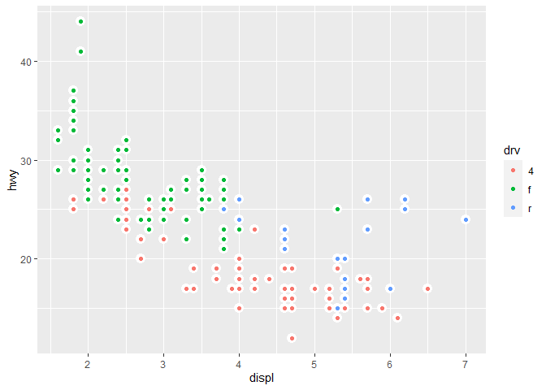

```r
ggplot(mpg, aes(x = displ, y = hwy)) +
  geom_point(size = 4, color = "white") +
  geom_point(aes(colour = drv))
```

## Grafik kao alat komunikacije

Nauka o podacima u R-u, Čas vežbi, 02-12-2020

U okviru ovog dela fokus je na mogućnostima ggplot2 paketa u cilju kreiranja kvalitetnih grafika i dodavanja neophodnih elemenata. Elementi grafika koji su neophodni kako bi kreirali dobar grafik, koji krajnjem korisniku nudi pravi uvid u podatke i nije dvosmislen, odnosi se na oznake koje svaki grafik treba da ima, anotacije, razmeru osa, legendu, temu i čuvanje grafika u visokoj rezolciji.

### Oznake grafika

Pre svega dobar grafik mora imati naslov koji verno opisuje podatke (title), a opciono i podnaslov (subtitle), komentar (caption) i nazive po osama (xlab, ylab).

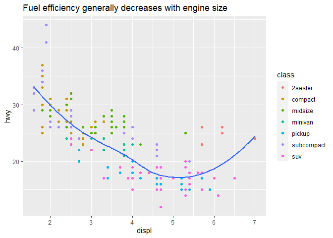

```r
ggplot(mpg, aes(displ, hwy)) +
  geom_point(aes(color = class)) +
  geom_smooth(se = FALSE) +
  labs(title = "Fuel efficiency generally decreases with engine size")
```

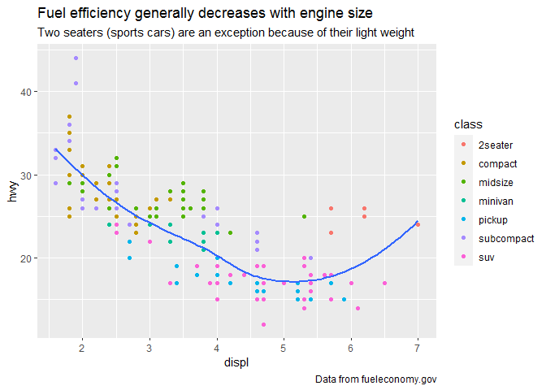

```r
ggplot(mpg, aes(displ, hwy)) +
  geom_point(aes(color = class)) +
  geom_smooth(se = FALSE) +
  labs(
    title = "Fuel efficiency generally decreases with engine size",
    subtitle = "Two seaters (sports cars) are an exception because of their light weight",
    caption = "Data from fueleconomy.gov"
  )
```

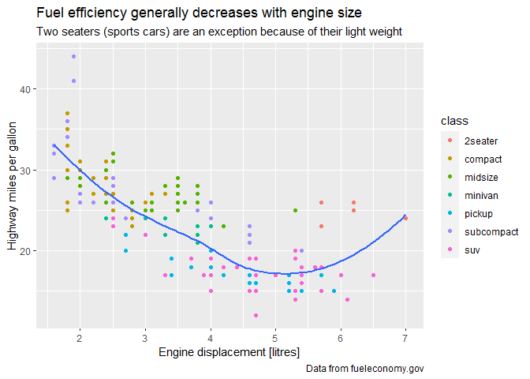

```r
ggplot(mpg, aes(displ, hwy)) +
  geom_point(aes(color = class)) +
  geom_smooth(se = FALSE) +
  labs(
    title = "Fuel efficiency generally decreases with engine size",
    subtitle = "Two seaters (sports cars) are an exception because of their light weight",
    caption = "Data from fueleconomy.gov",
    x = "Engine displacement [litres]",
    y = "Highway miles per gallon"
  )
```

### Anotacije

Kao što je bitno da imamo generalno naslov i podnaslov, kao i nazive osa čime definišemo glavne komponente grafika, isto tako je ponekad korisno da postavimo anotacije - označimo merene vrednosti ili grupe merenih vrednosti na grafiku.

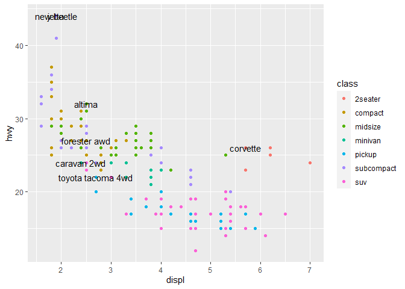

```r
# pull out the most efficient car in each class with dplyr, and then label it on the plot

best_in_class <- mpg %>%
  group_by(class) %>%
  filter(row_number(desc(hwy)) == 1)


ggplot(mpg, aes(displ, hwy)) +
  geom_point(aes(colour = class)) +
  geom_text(data = best_in_class, aes(x = displ, y = hwy, label = model))
```

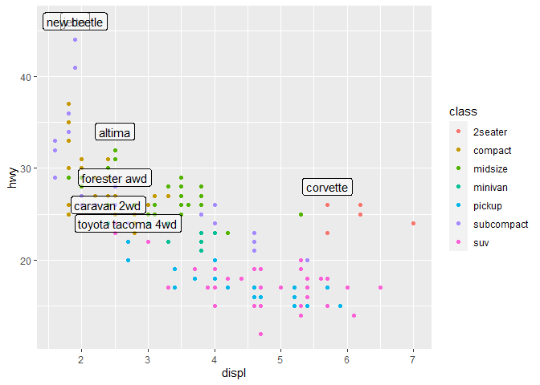

```r
ggplot(mpg, aes(displ, hwy)) +
  geom_point(aes(colour = class)) +
  geom_label(aes(label = model), data = best_in_class, nudge_y = 2, alpha = 0.5)
```

Da ne bi imali preklapanja u anotacijama, možemo korstiti paket ggrepel. Paket automatski pomera anotacije kako se ne bi preklapale.

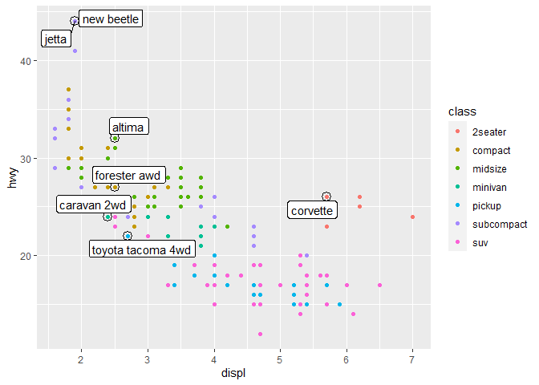

```r
ggplot(mpg, aes(displ, hwy)) +
  geom_point(aes(colour = class)) +
  geom_point(data = best_in_class, size = 4, shape = 1) +
  ggrepel::geom_label_repel(data = best_in_class, aes(label = model))
```

Ako želimo da postavimo anotacije po grupama - klasama, to možemo uraditi na sledeći način.

```r
class_avg <- mpg %>%
  group_by(class) %>%
  summarise(
    displ = median(displ),
    hwy = median(hwy)
  )
class_avg
```

```
## # A tibble: 7 x 3
##   class      displ   hwy
##   <chr>      <dbl> <dbl>
## 1 2seater     6.2   25
## 2 compact     2.2   27
## 3 midsize     2.8   27
## 4 minivan     3.3   23
## 5 pickup      4.7   17
## 6 subcompact  2.2   26
## 7 suv         4.65  17.5
```

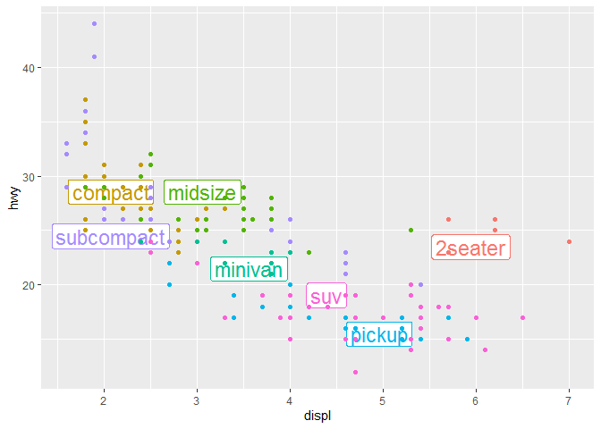

```r
ggplot(mpg, aes(displ, hwy, colour = class)) +
  ggrepel::geom_label_repel(aes(label = class),
    data = class_avg,
    size = 6,
    label.size = 0,
    segment.color = NA
  ) +
  geom_point() +
  theme(legend.position = "none")
```